# Homework 1 - Question 3

## Dataset

```python
import os
import random

import torch
from sklearn.datasets import fetch_openml
from sklearn.model_selection import train_test_split
import time


def configure_seed(seed):
    os.environ["PYTHONHASHSEED"] = str(seed)
    random.seed(seed)
    np.random.seed(seed)
    torch.manual_seed(seed)
    if torch.cuda.is_available():
        torch.cuda.manual_seed(seed)
        torch.backends.cudnn.deterministic = True
        torch.backends.cudnn.benchmark = False


def fetch_classification_data(dataset="Fashion-MNIST", random_state=42):
    """
    Loads the dataset from openml, normalizes feature values (by dividing
    everything by 256), and saves to an npz file.

    dataset: the name of the dataset (accepted: "mnist_784", "Fashion-MNIST")
    """
    assert dataset in {"mnist_784", "Fashion-MNIST"}
    start_time = time.time()
    X, y = fetch_openml(dataset, version=1, return_X_y=True, as_frame=False)
    print("Downloaded data in {:.4f} seconds".format(time.time() - start_time))
    X /= 256  # normalize
    y = y.astype(int)  # fetch_openml loads it as a str
    train_dev_X, train_dev_y = X[:60000], y[:60000]
    train_X, dev_X, train_y, dev_y = train_test_split(
        train_dev_X, train_dev_y, train_size=50000, test_size=10000, random_state=random_state
    )
    test_X, test_y = X[60000:], y[60000:]
    np.savez_compressed(
        dataset + ".npz",
        Xtrain=train_X, ytrain=train_y,
        Xdev=dev_X, ydev=dev_y,
        Xtest=test_X, ytest=test_y
    )


def load_classification_data(bias=False):
    """
    Loads the preprocessed, featurized fashion-mnist dataset from
    Fashion-MNIST.npz, optionally adding a bias feature.
    """
    data = np.load('Fashion-MNIST.npz')
    train_X = data["Xtrain"]
    dev_X = data["Xdev"]
    test_X = data["Xtest"]
    if bias:
        train_X = np.hstack((train_X, np.ones((train_X.shape[0], 1))))
        dev_X = np.hstack((dev_X, np.ones((dev_X.shape[0], 1))))
        test_X = np.hstack((test_X, np.ones((test_X.shape[0], 1))))
    return {"train": (train_X, data["ytrain"]),
            "dev": (dev_X, data["ydev"]),
            "test": (test_X, data["ytest"])}


def load_regression_data(bias=False):
    """
    Loads the preprocessed, featurized Ames housing dataset from ames.npz.
    """
    data = np.load('ames.npz')
    train_X = data["Xtrain"]
    test_X = data["Xtest"]
    train_y = data["ytrain"].reshape(-1)
    test_y = data["ytest"].reshape(-1)
    if bias:
        train_X = np.hstack((train_X, np.ones((train_X.shape[0], 1))))
        test_X = np.hstack((test_X, np.ones((test_X.shape[0], 1))))
    return {"train": (train_X, train_y),
            "test": (test_X, test_y)}


class ClassificationDataset(torch.utils.data.Dataset):

    def __init__(self, data):
        """
        data: the dict returned by utils.load_classification_data
        """
        train_X, train_y = data["train"]
        dev_X, dev_y = data["dev"]
        test_X, test_y = data["test"]

        self.X = torch.tensor(train_X, dtype=torch.float32)
        self.y = torch.tensor(train_y, dtype=torch.long)

        self.dev_X = torch.tensor(dev_X, dtype=torch.float32)
        self.dev_y = torch.tensor(dev_y, dtype=torch.long)

        self.test_X = torch.tensor(test_X, dtype=torch.float32)
        self.test_y = torch.tensor(test_y, dtype=torch.long)

    def __len__(self):
        return len(self.X)

    def __getitem__(self, idx):
        return self.X[idx], self.y[idx]
```

## 1 (a)

Implement the `update_weights` method of the Perceptron class in hw1-q3.py. Then train 20 epochs of the perceptron on the training set and report its performance on the validation and test set. Plot the accuracies as a function of the epoch number.

```python
import argparse
import random
import os

import numpy as np
import matplotlib.pyplot as plt

import utils
```

```python
def configure_seed(seed):
    os.environ["PYTHONHASHSEED"] = str(seed)
    random.seed(seed)
    np.random.seed(seed)
```

```python
class LinearModel(object):
    def __init__(self, n_classes, n_features, **kwargs):
        self.W = np.zeros((n_classes, n_features))

    def update_weight(self, x_i, y_i, **kwargs):
        raise NotImplementedError

    def train_epoch(self, X, y, **kwargs):
        for x_i, y_i in zip(X, y):
            self.update_weight(x_i, y_i, **kwargs)

    def predict(self, X):
        """X (n_examples x n_features)"""
        scores = np.dot(self.W, X.T)  # (n_classes x n_examples)
        predicted_labels = scores.argmax(axis=0)  # (n_examples)
        return predicted_labels

    def evaluate(self, X, y):
        """
        X (n_examples x n_features):
        y (n_examples): gold labels
        """
        y_hat = self.predict(X)
        n_correct = (y == y_hat).sum()
        n_possible = y.shape[0]
        return n_correct / n_possible
```

```python
class Perceptron(LinearModel):
    def update_weight(self, x_i, y_i, **kwargs):
        """
        x_i (n_features): a single training example
        y_i (scalar): the gold label for that example
        other arguments are ignored
        """
        # Q3.1a

        # obtain predicted class
        y_hat = np.argmax(np.dot(self.W, x_i.T), axis = 0)

        # update parameters
        if y_hat != y_i:

            # update weights of true class
            self.W[y_i] += x_i
            # update weights of predicted class
            self.W[y_hat] -= x_i

        return self.W
```

```python
def plot(epochs, valid_accs, test_accs):
    plt.xlabel('Epoch')
    plt.ylabel('Accuracy')
    plt.xticks(epochs)
    plt.plot(epochs, valid_accs, label='validation')
    plt.plot(epochs, test_accs, label='test')
    plt.legend()
    plt.show()
```

```python
def main(model = 'perceptron', n_epochs = 20, hidden_size = 200, layers = 1, learning_rate = 0.001):
    """
        model:            model to be used
                          'perceptron', 'logistic_regression', 'mlp'
        n_epochs:         number of epochs to train for
        hidden_size:      number of units in hidden layers
        layers:           number of hidden layers
        learning_rate:    learning rate for parameter updates
        """

    configure_seed(seed=42)

    add_bias = model != "mlp"
    data = load_classification_data(bias=add_bias)
    train_X, train_y = data["train"]
    dev_X, dev_y = data["dev"]
    test_X, test_y = data["test"]

    n_classes = np.unique(train_y).size  # 10
    n_feats = train_X.shape[1]

    # initialize the model
    if model == 'perceptron':
        model = Perceptron(n_classes, n_feats)
    elif model == 'logistic_regression':
        model = LogisticRegression(n_classes, n_feats)
    else:
        model = MLP(n_classes, n_feats, hidden_size, layers)

    epochs = np.arange(1, n_epochs + 1)
    valid_accs = []
    test_accs = []

    for i in epochs:
        print('Training epoch {}'.format(i))
        train_order = np.random.permutation(train_X.shape[0])
        train_X = train_X[train_order]
        train_y = train_y[train_order]
        model.train_epoch(
            train_X,
            train_y,
            learning_rate=learning_rate
        )
        valid_accs.append(model.evaluate(dev_X, dev_y))
        test_accs.append(model.evaluate(test_X, test_y))
        print('Accuracy (val): %.3f | Accuracy (test): %.3f' % (valid_accs[-1], test_accs[-1]))

    # plot
    plot(epochs, valid_accs, test_accs)
```

```
Training epoch 1
Accuracy (val): 0.796 | Accuracy (test): 0.785
Training epoch 2
Accuracy (val): 0.742 | Accuracy (test): 0.734
Training epoch 3
Accuracy (val): 0.817 | Accuracy (test): 0.811
Training epoch 4
Accuracy (val): 0.773 | Accuracy (test): 0.766
Training epoch 5
Accuracy (val): 0.742 | Accuracy (test): 0.733
Training epoch 6
Accuracy (val): 0.801 | Accuracy (test): 0.795
Training epoch 7
Accuracy (val): 0.790 | Accuracy (test): 0.783
Training epoch 8
Accuracy (val): 0.783 | Accuracy (test): 0.779
Training epoch 9
Accuracy (val): 0.802 | Accuracy (test): 0.795
Training epoch 10
Accuracy (val): 0.811 | Accuracy (test): 0.801
Training epoch 11
Accuracy (val): 0.756 | Accuracy (test): 0.754
Training epoch 12
Accuracy (val): 0.808 | Accuracy (test): 0.804
Training epoch 13
Accuracy (val): 0.826 | Accuracy (test): 0.820
Training epoch 14
Accuracy (val): 0.759 | Accuracy (test): 0.750
Training epoch 15
Accuracy (val): 0.725 | Accuracy (test): 0.720
Training epoch 16
Accuracy (val): 0.803 | Accuracy (test): 0.799
Training epoch 17
Accuracy (val): 0.811 | Accuracy (test): 0.802
Training epoch 18
Accuracy (val): 0.779 | Accuracy (test): 0.773
Training epoch 19
Accuracy (val): 0.810 | Accuracy (test): 0.800
Training epoch 20
Accuracy (val): 0.713 | Accuracy (test): 0.701
```

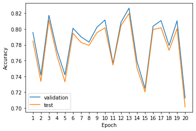

```python
main(model = 'perceptron', n_epochs = 20, hidden_size = 200, layers = 1, learning_rate = 0.001)
```

## 1 (b)

Repeat the same exercise using logistic regression instead (without regularization), using stochastic gradient descent as your training algorithm. Set a fixed learning rate `η = 0.001`. This can be solved by implementing the `update_weights` method in the `LogisticRegression` class.

```python
import argparse
import random
import os

import numpy as np
import matplotlib.pyplot as plt

import utils
```

```python
def configure_seed(seed):
    os.environ["PYTHONHASHSEED"] = str(seed)
    random.seed(seed)
    np.random.seed(seed)
```

```python
class LinearModel(object):
    def __init__(self, n_classes, n_features, **kwargs):
        self.W = np.zeros((n_classes, n_features))

    def update_weight(self, x_i, y_i, **kwargs):
        raise NotImplementedError

    def train_epoch(self, X, y, **kwargs):
        for x_i, y_i in zip(X, y):
            self.update_weight(x_i, y_i, **kwargs)

    def predict(self, X):
        """X (n_examples x n_features)"""
        scores = np.dot(self.W, X.T)  # (n_classes x n_examples)
        predicted_labels = scores.argmax(axis=0)  # (n_examples)
        return predicted_labels

    def evaluate(self, X, y):
        """
        X (n_examples x n_features):
        y (n_examples): gold labels
        """
        y_hat = self.predict(X)
        n_correct = (y == y_hat).sum()
        n_possible = y.shape[0]
        return n_correct / n_possible
```

```python
class LogisticRegression(LinearModel):
    def update_weight(self, x_i, y_i, learning_rate=0.001):
        """
        x_i (n_features): a single training example
        y_i: the gold label for that example
        learning_rate (float): keep it at the default value for your plots
        """
        # Q3.1b

        # Label scores according to the model (n_classes,)
        scores = np.dot(self.W, x_i)

        # One-hot vector with the true label (n_classes,)
        y_one_hot = np.zeros(self.W.shape[0])
        y_one_hot[y_i] = 1

        # Softmax function.
        # This gives the label probabilities according to the model (n_classes,)
        label_probabilities = np.exp(scores) / np.sum(np.exp(scores))

        # SGD update. W is n_classes x n_features.
        self.W += learning_rate * (y_one_hot - label_probabilities)[:,None] * x_i.T

        return self.W
```

```python
def plot(epochs, valid_accs, test_accs):
    plt.xlabel('Epoch')
    plt.ylabel('Accuracy')
    plt.xticks(epochs)
    plt.plot(epochs, valid_accs, label='validation')
    plt.plot(epochs, test_accs, label='test')
    plt.legend()
    plt.show()
```

```python
def main(model = 'perceptron', n_epochs = 20, hidden_size = 200, layers = 1, learning_rate = 0.001):
    """
        model:            model to be used
                          'perceptron', 'logistic_regression', 'mlp'
        n_epochs:         number of epochs to train for
        hidden_size:      number of units in hidden layers
        layers:           number of hidden layers
        learning_rate:    learning rate for parameter updates
        """

    configure_seed(seed=42)

    add_bias = model != "mlp"
    data = load_classification_data(bias=add_bias)
    train_X, train_y = data["train"]
    dev_X, dev_y = data["dev"]
    test_X, test_y = data["test"]

    n_classes = np.unique(train_y).size  # 10
    n_feats = train_X.shape[1]

    # initialize the model
    if model == 'perceptron':
        model = Perceptron(n_classes, n_feats)
    elif model == 'logistic_regression':
        model = LogisticRegression(n_classes, n_feats)
    else:
        model = MLP(n_classes, n_feats, hidden_size, layers)

    epochs = np.arange(1, n_epochs + 1)
    valid_accs = []
    test_accs = []

    for i in epochs:
        print('Training epoch {}'.format(i))
        train_order = np.random.permutation(train_X.shape[0])
        train_X = train_X[train_order]
        train_y = train_y[train_order]
        model.train_epoch(
            train_X,
            train_y,
            learning_rate=learning_rate
        )
        valid_accs.append(model.evaluate(dev_X, dev_y))
        test_accs.append(model.evaluate(test_X, test_y))
        print('Accuracy (val): %.3f | Accuracy (test): %.3f' % (valid_accs[-1], test_accs[-1]))

    # plot
    plot(epochs, valid_accs, test_accs)
```

```
Training epoch 1
Accuracy (val): 0.819 | Accuracy (test): 0.812
Training epoch 2
Accuracy (val): 0.831 | Accuracy (test): 0.822
Training epoch 3
Accuracy (val): 0.837 | Accuracy (test): 0.829
Training epoch 4
Accuracy (val): 0.835 | Accuracy (test): 0.828
Training epoch 5
Accuracy (val): 0.837 | Accuracy (test): 0.829
Training epoch 6
Accuracy (val): 0.839 | Accuracy (test): 0.827
Training epoch 7
Accuracy (val): 0.845 | Accuracy (test): 0.835
Training epoch 8
Accuracy (val): 0.847 | Accuracy (test): 0.838
Training epoch 9
Accuracy (val): 0.847 | Accuracy (test): 0.837
Training epoch 10
Accuracy (val): 0.845 | Accuracy (test): 0.836
Training epoch 11
Accuracy (val): 0.850 | Accuracy (test): 0.838
Training epoch 12
Accuracy (val): 0.851 | Accuracy (test): 0.839
Training epoch 13
Accuracy (val): 0.849 | Accuracy (test): 0.839
Training epoch 14
Accuracy (val): 0.848 | Accuracy (test): 0.838
Training epoch 15
Accuracy (val): 0.851 | Accuracy (test): 0.840
Training epoch 16
Accuracy (val): 0.852 | Accuracy (test): 0.842
Training epoch 17
Accuracy (val): 0.849 | Accuracy (test): 0.839
Training epoch 18
Accuracy (val): 0.850 | Accuracy (test): 0.839
Training epoch 19
Accuracy (val): 0.851 | Accuracy (test): 0.840
Training epoch 20
Accuracy (val): 0.850 | Accuracy (test): 0.840
```

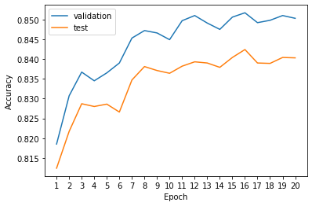

```python
main(model = 'logistic_regression', n_epochs = 20, hidden_size = 200, layers = 1, learning_rate = 0.001)
```

## 2 (b)

**Without using any neural network toolkit**, implement a multi-layer perceptron with a single hidden layer to solve this problem, including the gradient backpropagation algorithm which is needed to train the model. Use `200 hidden units`, a `relu activation function` for the hidden layers, and a `multinomial logistic loss` (also called cross-entropy) in the output layer. Don’t forget to include bias terms in your hidden units. Train the model with stochastic gradient descent with a `learning rate of 0.001`. Initialize biases with zero vectors and values in weight matrices with $ wij ∼ N(µ,σ^2) $ with $ µ = 0.1 $ and $σ^2 = 0.1^2 $ (hint: use numpy.random.normal).

```python
import argparse
import random
import os

import numpy as np
import matplotlib.pyplot as plt

import utils
```

```python
def configure_seed(seed):
    os.environ["PYTHONHASHSEED"] = str(seed)
    random.seed(seed)
    np.random.seed(seed)
```

```python
class MLP(object):
    # Q3.2b. This MLP skeleton code allows the MLP to be used in place of the
    # linear models with no changes to the training loop or evaluation code
    # in main().
    def __init__(self, n_classes, n_features, hidden_size, layers):
        # Initialize an MLP with a single hidden layer.
        self.n_classes = n_classes
        self.n_features = n_features
        self.hidden_size = hidden_size
        self.layers = layers
        # Initialize weights (W1, ..., W(layers+1))
        self.weights = []
        for i in range(layers + 1):
            if i == 0:
                self.weights.append(np.random.normal(0.1, 0.1, size = (n_features, hidden_size)))
            elif i == layers:
                self.weights.append(np.random.normal(0.1, 0.1, size = (hidden_size, n_classes)))
            else:
                self.weights.append(np.random.normal(0.1, 0.1, size = (hidden_size, hidden_size)))

        # Initialize biases (b1, ..., b(layers+1))
        self.biases = []
        for i in range(layers + 1):
            if i == 0:
                self.biases.append(np.zeros(hidden_size))
            elif i == layers:
                self.biases.append(np.zeros(n_classes))
            else:
                self.biases.append(np.zeros(hidden_size))

    def predict(self, X):
        # Compute the forward pass of the network. At prediction time, there is
        # no need to save the values of hidden nodes, whereas this is required
        # at training time.
        hiddens = []
        for i in range(self.layers + 1):
            h = X if i == 0 else hiddens[i-1]
            z = np.dot(h, self.weights[i]) + self.biases[i]
            if i < self.layers:
                hiddens.append(np.maximum(z, 0))
        output = z
        yhat = np.argmax(output, axis = 1)
        return yhat


    def evaluate(self, X, y):
        """
        X (n_examples x n_features)
        y (n_examples): gold labels
        """
        # Identical to LinearModel.evaluate()
        y_hat = self.predict(X)
        n_correct = (y == y_hat).sum()
        n_possible = y.shape[0]
        return n_correct / n_possible

    def train_epoch(self, X, y, learning_rate=0.001):

        # stochastic gradient descent
        for x_i, y_i in zip(X, y):

            # forward pass:
            hiddens = []
            for i in range(self.layers + 1):
                h = x_i if i == 0 else hiddens[i-1]
                z = np.dot(h, self.weights[i]) + self.biases[i]
                if i < self.layers:
                    hiddens.append(np.maximum(z,0))
            yhat = z

            # backward pass:

            # softmax activations
            probs = np.exp(yhat - np.max(yhat)) / np.sum(np.exp(yhat - np.max(yhat)))
            # one hot encoded vector of true class
            y_i_one_hot_vector = np.zeros(self.n_classes)
            y_i_one_hot_vector[y_i] = 1

            # dL/dz
            grad_z = probs - y_i_one_hot_vector # (n_classes,)

            grad_weights = []
            grad_biases = []

            for i in range(self.layers, -1, -1):

                h = x_i if i == 0 else hiddens[i-1]
                # compute gradient of parameters:
                grad_weights.append(np.dot(h[:,None], grad_z[:,None].T))
                grad_biases.append(grad_z)

                # compute gradient of hidden layer after activation function:
                grad_h = np.dot(grad_z, self.weights[i].T)

                # compute gradient of hidden layer before activation:
                grad_z = grad_h * (h > 0) # (h > 0) to get the gradient of the ReLU

            grad_weights.reverse()
            grad_biases.reverse()

            # updating the weights
            for i in range(self.layers + 1):
                self.weights[i] -= learning_rate * grad_weights[i]
                self.biases[i] -= learning_rate * grad_biases[i]

        return self.weights, self.biases
```

```python
def plot(epochs, valid_accs, test_accs):
    plt.xlabel('Epoch')
    plt.ylabel('Accuracy')
    plt.xticks(epochs)
    plt.plot(epochs, valid_accs, label='validation')
    plt.plot(epochs, test_accs, label='test')
    plt.legend()
    plt.show()
```

```python
def main(model = 'perceptron', n_epochs = 20, hidden_size = 200, layers = 1, learning_rate = 0.001):
    """
        model:            model to be used
                          'perceptron', 'logistic_regression', 'mlp'
        n_epochs:         number of epochs to train for
        hidden_size:      number of units in hidden layers
        layers:           number of hidden layers
        learning_rate:    learning rate for parameter updates
        """

    configure_seed(seed=42)

    add_bias = model != "mlp"
    data = load_classification_data(bias=add_bias)
    train_X, train_y = data["train"]
    dev_X, dev_y = data["dev"]
    test_X, test_y = data["test"]

    n_classes = np.unique(train_y).size  # 10
    n_feats = train_X.shape[1]

    # initialize the model
    if model == 'perceptron':
        model = Perceptron(n_classes, n_feats)
    elif model == 'logistic_regression':
        model = LogisticRegression(n_classes, n_feats)
    else:
        model = MLP(n_classes, n_feats, hidden_size, layers)

    epochs = np.arange(1, n_epochs + 1)
    valid_accs = []
    test_accs = []

    for i in epochs:
        print('Training epoch {}'.format(i))
        train_order = np.random.permutation(train_X.shape[0])
        train_X = train_X[train_order]
        train_y = train_y[train_order]
        model.train_epoch(
            train_X,
            train_y,
            learning_rate=learning_rate
        )
        valid_accs.append(model.evaluate(dev_X, dev_y))
        test_accs.append(model.evaluate(test_X, test_y))
        print('Accuracy (val): %.3f | Accuracy (test): %.3f' % (valid_accs[-1], test_accs[-1]))

    # plot
    plot(epochs, valid_accs, test_accs)
```

```
Training epoch 1
Accuracy (val): 0.802 | Accuracy (test): 0.799
Training epoch 2
Accuracy (val): 0.837 | Accuracy (test): 0.828
Training epoch 3
Accuracy (val): 0.845 | Accuracy (test): 0.837
Training epoch 4
Accuracy (val): 0.855 | Accuracy (test): 0.841
Training epoch 5
Accuracy (val): 0.853 | Accuracy (test): 0.844
Training epoch 6
Accuracy (val): 0.857 | Accuracy (test): 0.846
Training epoch 7
Accuracy (val): 0.866 | Accuracy (test): 0.857
Training epoch 8
Accuracy (val): 0.860 | Accuracy (test): 0.853
Training epoch 9
Accuracy (val): 0.862 | Accuracy (test): 0.855
Training epoch 10
Accuracy (val): 0.865 | Accuracy (test): 0.856
Training epoch 11
Accuracy (val): 0.863 | Accuracy (test): 0.851
Training epoch 12
Accuracy (val): 0.866 | Accuracy (test): 0.853
Training epoch 13
Accuracy (val): 0.869 | Accuracy (test): 0.863
Training epoch 14
Accuracy (val): 0.872 | Accuracy (test): 0.865
Training epoch 15
Accuracy (val): 0.875 | Accuracy (test): 0.866
Training epoch 16
Accuracy (val): 0.867 | Accuracy (test): 0.860
Training epoch 17
Accuracy (val): 0.877 | Accuracy (test): 0.868
Training epoch 18
Accuracy (val): 0.874 | Accuracy (test): 0.863
Training epoch 19
Accuracy (val): 0.872 | Accuracy (test): 0.861
Training epoch 20
Accuracy (val): 0.877 | Accuracy (test): 0.865
```

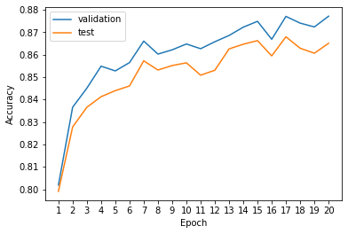

```python
main(model = 'mlp', n_epochs = 20, hidden_size = 200, layers = 1, learning_rate = 0.001)
```